# Hackathon-IE6600-SEC03-GROUP14

# Conclusion

In order to understand the maximum and the minimum amount earned by an employee in an organization, we take some of the most desired fields in the world, Information Systems and Professional Engineering. We can see that the maximum range of salary for an information systems professional is between 150k and 100k and the minimum range is between 25k to 55k. Similarly, the maximum range for an engineering professional is between 160k and 125k and the minimum range is between 70k and 10k. In order to compensate employees fairly, it is important to understand the maximum and the minimum amount earned by an employee in any field.

# Overtime Data

# Question 5: How much does overtime cost the company? What is the maximum and the average value of the overtime money?

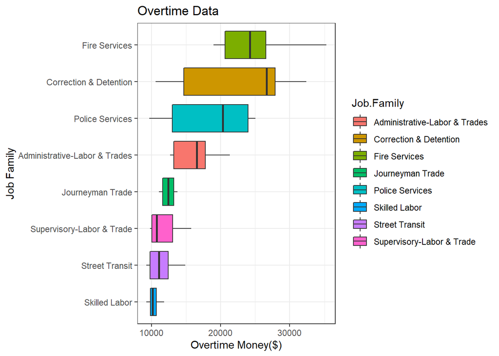

# Conclusion

Incentives and overtime money are another important factor in deciding the compensation pay of an employee. It is important to understand the average overtime amount earned by the employee and the maximum amount as well. This helps the company to set incentives based on the work load. We can see that the job families with most overtime are Fire Services and Correction and Detention. Incentives also depend on the the total salary of an employee. High paying jobs such as that of information systems and professional engineering have less overtime hours.

# Benefits

# Question 6: How much benefits are given to the top ranked employees in some of the most desired job families?

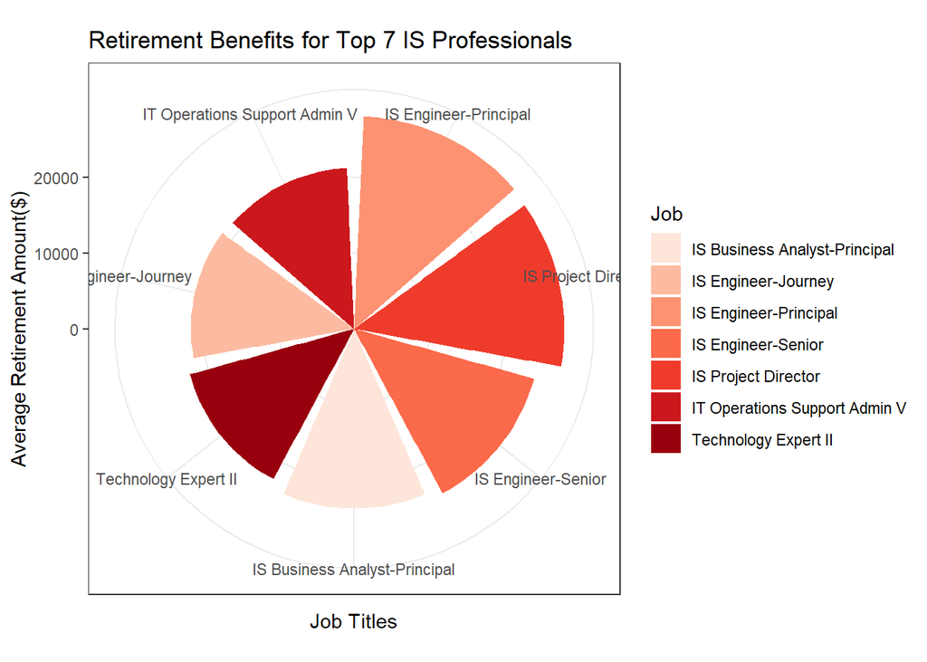

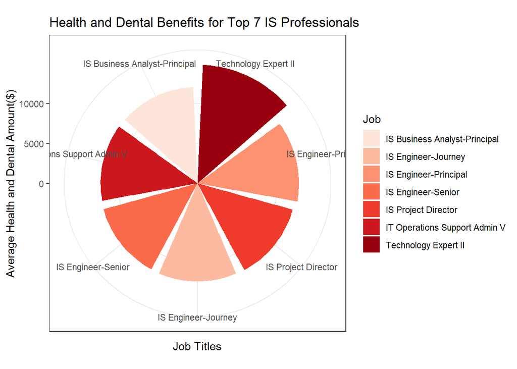

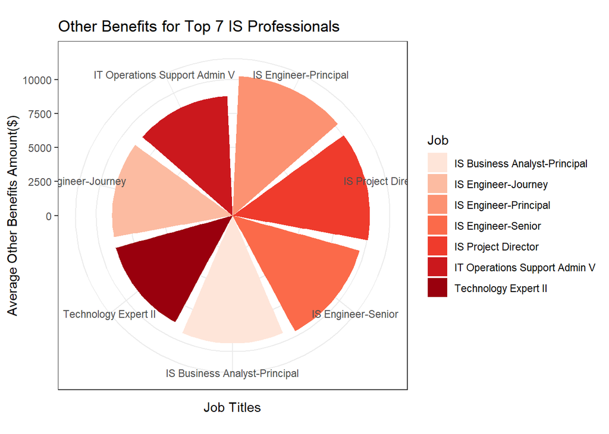

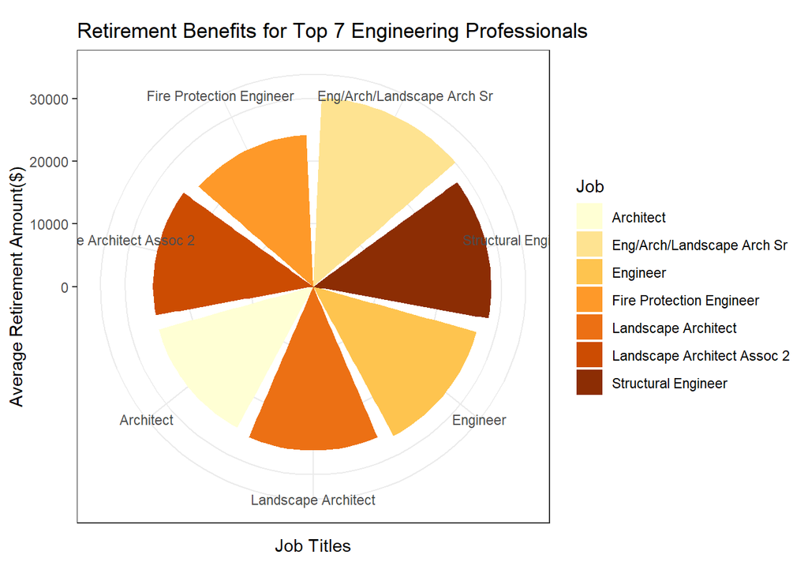

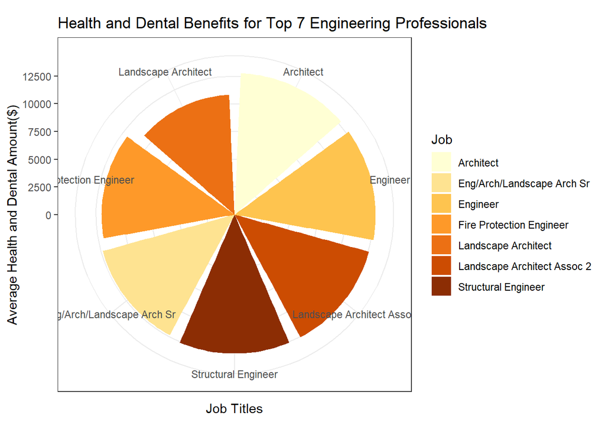

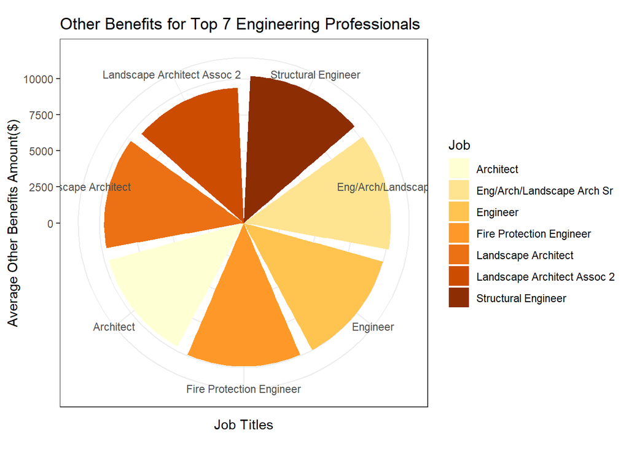